# Projekt modele liniowe i mieszane

Zadanie V

Aleksandra Dąbrowska, Jan Dmitruk, Magda Młynarczyk

# 1 Przedstawienie problemu

W piątej fazie zadania rozpatrzymy interakcje występujące między zmiennymi objaśniającymi wybranymi przez nas w poprzednich etapach. Następnie zmodyfikujemy nasz model, uwzględniając istotne interakcje oraz zbadamy ich wpływ na jakość modelu.

Zauważmy, że w poniższych rozważaniach modelujemy logarytm czasu zadania.

# 2 Podsumowanie

Spośród naszych zmiennych zainteresowały nas interakcje między efektami:

- zadania i jego pozycji w kwestionariuszu 3.1
- wykształcenia matki i ojca 3.2
- kraju i płci ucznia 3.3

Zauważyliśmy, że w każdym wypadku taka interakcja istnieje. Po dodaniu ich do modelu okazało się, że wszystkie one są statystycznie istotne.

# 3 Analiza interakcji

W celu znalezienia interakcji w naszym modelu przedstawimy i omówimy wykresy interakcji efektów wybranych zmiennych.

## 3.1 Interakcja między zadaniem, a jego pozycją w kwestionariuszu

Wydaje nam się, że czas rozwiązania danego zadania może zależeć od jego pozycji w kwestionariuszu. Na przykład uczeń poświęca więcej czasu na długie zadanie na pierwszej pozycji, a pomija je na ostatnich.

Przypomnijmy na początku rozważany przez nas model w 3 i 4 fazie projektu.

```r
model <- lm(log(czas_zadania)~zadanie+pozycja_zadania+id_kwestionariusza+plec+mies_ur+id_kraju+wyk_m+wyk_o+gr_zawod_m+gr_zawod_o+stat_m+stat_o, data = dane_nowe)
```

Na poniższym wykresie przedstawimy rozważaną interakcję między numerem zadania, a jego pozycją w kwestionariuszu.

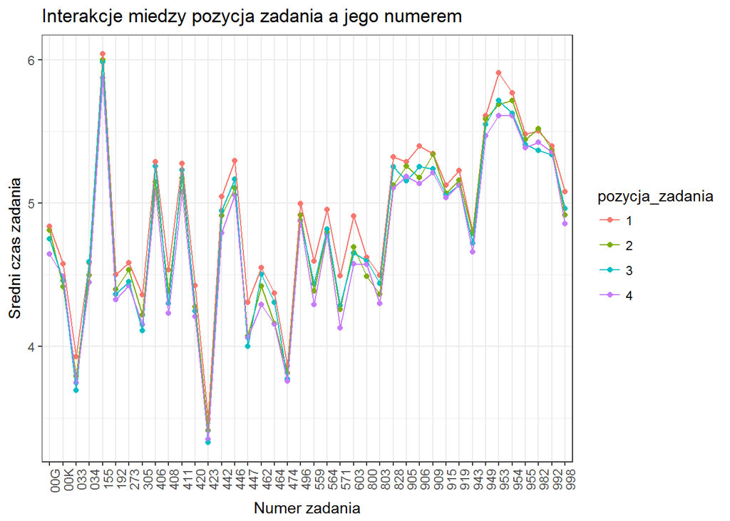

```r
int1 <- ddply(dane_nowe,.(zadanie,pozycja_zadania),summarise, val = mean(log(czas_zadania)))

ggplot(dane_nowe, aes(x = factor(zadanie), y = log(czas_zadania), colour = pozycja_zadania)) +
    geom_point(data = int1, aes(y = val)) +
    geom_line(data = int1, aes(y = val, group = pozycja_zadania)) +
    theme_bw()+
    theme(axis.text.x = element_text(angle = 90, hjust = 1))+
    xlab("Numer zadania")+
    ylab("Średni czas zadania")+
    ggtitle("Interakcje między pozycją zadania a jego numerem")
```

Na powyższym wykresie widzimy, że dla niektórych zadań występują interakcje. Przyjrzyjmy się wybranym zadaniom, aby lepiej je zwizualizować.

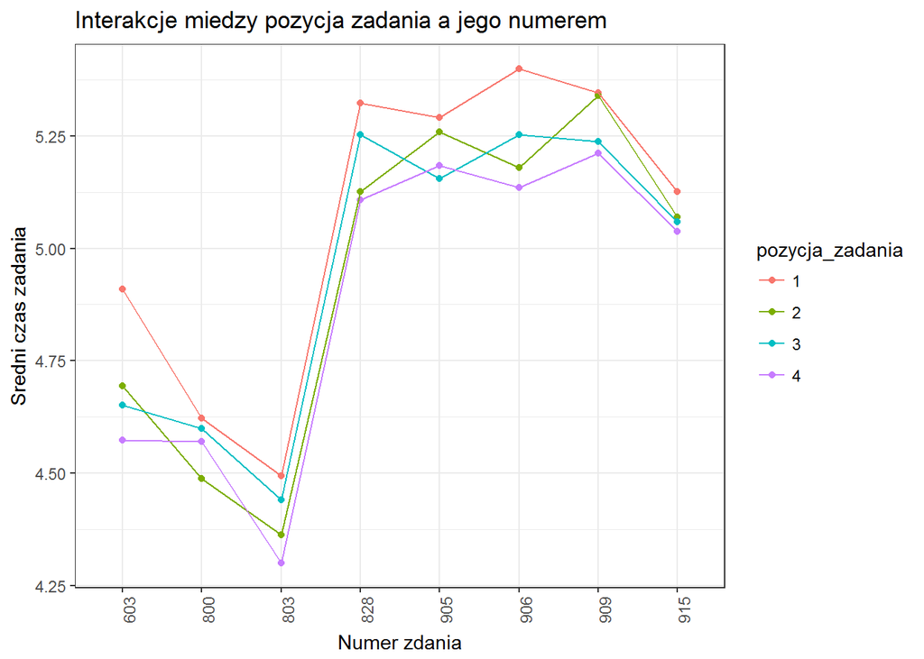

```r
dane_nowe_okrojone <- filter(dane_nowe, dane_nowe$zadanie %in% c("603", "800", "803", "828", "905", "906", "915", "909"))

int2 <- ddply(dane_nowe_okrojone,.(zadanie,pozycja_zadania),summarise, val = mean(log(czas_zadania)))

ggplot(dane_nowe_okrojone, aes(x = factor(zadanie), y = log(czas_zadania), colour = pozycja_zadania)) +
    geom_point(data = int2, aes(y = val)) +
    geom_line(data = int2, aes(y = val, group = pozycja_zadania)) +
    theme_bw()+theme(axis.text.x = element_text(angle = 90, hjust = 1))+
    xlab("Numer zdania")+
    ylab("Średni czas zadania")+
    ggtitle("Interakcje między pozycją zadania a jego numerem")
```

Faktycznie, zadanie 906 na pozycji 1 i 3, a więc rozwiązywane w pierwszych częściach testu, jest rozwiązywane dłużej, niż na pozycjach 2 i 4. Nie jest tak dla zadań 603, 905, 909 i 915.

## 3.2 Interakcja między wykształceniem matki i ojca

Sprawdźmy, czy wysokie wykształcenie zarówno matki i ojca ma wpływ na czas rozwiązywania zadania przez ich dziecko? Czy zmienia się to, kiedy jedno z rodziców ma niższe wykształcenie, albo oboje mają niskie wykształcenie?

Poziom wykształcenia oznaczany jest od najniższego do najwyższego kolejno: None,1,2,3,4,5,6 i odpowiadają one poziomom ISCED.

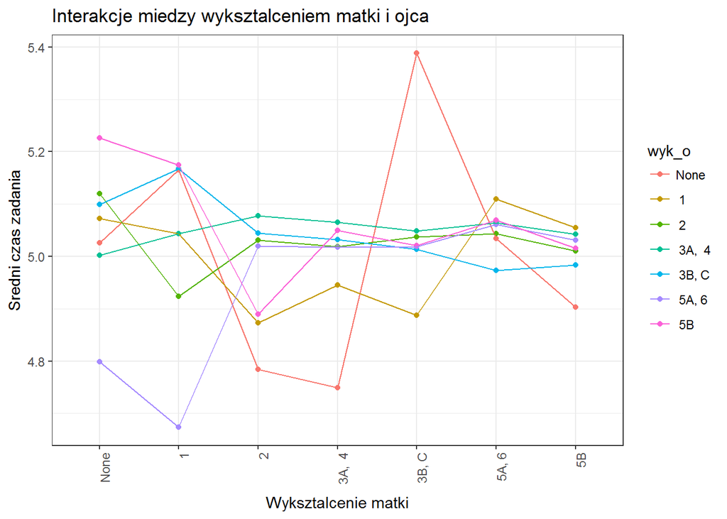

```r
dane_nowe$wyk_m <-  relevel(dane_nowe$wyk_m,ref="None")
dane_nowe$wyk_o <-  relevel(dane_nowe$wyk_o,ref="None")

int3 <- ddply(dane_nowe, .(wyk_m, wyk_o),summarise, val = mean(log(czas_zadania)))

ggplot(dane_nowe, aes(x = factor(wyk_m), y = log(czas_zadania), colour = wyk_o)) +
    geom_point(data = int3, aes(y = val)) +
    geom_line(data = int3, aes(y = val, group = wyk_o)) +
    theme_bw()+theme(axis.text.x = element_text(angle = 90, hjust = 1))+
    xlab("Wykształcenie matki")+
    ylab("Średni czas zadania")+
    ggtitle("Interakcje między wykształceniem matki i ojca ")
```

Przecinające się wykresy świadczą o istnieniu interakcji. Zauważamy największe interakcje w przypadku, gdy przynajmniej jeden z rodziców ma niskie wykształcenie. Nie widzimy natomiast, żeby wysokie wykształcenie jednego rodzica istotnie wpływało na czas rozwiązywania zadania (dla wyższych wykształceń linie mają podobne nachylenia).

## 3.3 Interakcja pomiędzy krajem a płcią

Czy w zależności od kraju widzimy różnice w wykształceniu dziewczynek i chłopców? Czy możliwe jest, że istnieje kraj, w którym dziewczynki albo chłopcy mają gorsze możliwości edukacji?

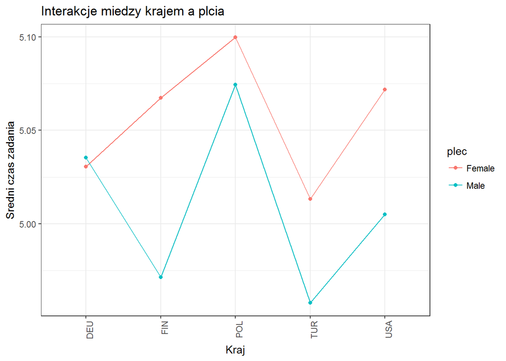

```r
int4 <- ddply(dane_nowe, .(plec, id_kraju),summarise, val = mean(log(czas_zadania)))

ggplot(dane_nowe, aes(x = factor(id_kraju), y = log(czas_zadania), colour = plec)) +
    geom_point(data = int4, aes(y = val)) +
    geom_line(data = int4, aes(y = val, group = plec)) +
    theme_bw()+theme(axis.text.x = element_text(angle = 90, hjust = 1))+
    xlab("Kraj")+
    ylab("Średni czas zadania")+
    ggtitle("Interakcje między krajem a płcią")
```

Powyższy wykres jest wyjątkowo interesujący - w Finlandii widzimy największa różnicę w czasie rozwiązywania zadania między chłopcami a dziewczynkami (a przypuszczaliśmy, że to może wydarzyć się w Turcji, co się po części potwierdziło). Na podstawie wykresu stwierdzamy istnienie interakcji.

# 4 Istotność interakcji w modelu

W celu zbadania istotności powyższych interakcji, modyfikujemy nasz model. Następnie wykonując analizę wariancji sprawdzamy istotnośćrozważanych powyżej interakcji.

```r
model2 <- lm(log(czas_zadania)~zadanie*pozycja_zadania+id_kwestionariusza+mies_ur+id_kraju*plec+wyk_m*wyk_o+gr_zawod_m+gr_zawod_o+stat_m+stat_o, data = dane_nowe)

anova(model2)
```

```
## Analysis of Variance Table
##
## Response: log(czas_zadania)
##                             Df Sum Sq Mean Sq   F value    Pr(>F)
## zadanie                     39  46528 1193.02 3770.9804 < 2.2e-16 ***
## pozycja_zadania              3    551  183.83  581.0625 < 2.2e-16 ***
## id_kwestionariusza          34    193    5.69   17.9747 < 2.2e-16 ***
## mies_ur                     11     23    2.13    6.7279 2.116e-11 ***
## id_kraju                     4    134   33.62  106.2791 < 2.2e-16 ***
## plec                         1     61   60.61  191.5671 < 2.2e-16 ***
## wyk_m                        6     39    6.55   20.7025 < 2.2e-16 ***
## wyk_o                        6     27    4.46   14.1116 3.907e-16 ***
## gr_zawod_m                  37    177    4.79   15.1350 < 2.2e-16 ***
## gr_zawod_o                  41    133    3.24   10.2391 < 2.2e-16 ***
## stat_m                       4     13    3.28   10.3523 2.217e-08 ***
## stat_o                       4     14    3.39   10.7228 1.093e-08 ***
## zadanie:pozycja_zadania    107    199    1.86    5.8669 < 2.2e-16 ***
## id_kraju:plec                4     70   17.45   55.1589 < 2.2e-16 ***
## wyk_m:wyk_o                 36     72    2.01    6.3538 < 2.2e-16 ***
## Residuals               149410  47269    0.32
## ---
## Signif. codes:  0 '***' 0.001 '**' 0.01 '*' 0.05 '.' 0.1 ' ' 1
```

Wyniki funkcji `anova()` pokazują, że wszystkie badane interakcje są istotne dla naszego nowego modelu.